# AMR Data Visualization in R

A Step-by-Step Teaching Guide for AMR Surveillance Professionals

Alfred Bortey (DR. AMR)

May 07, 2026

**Welcome to AMR Data Visualization**

By the end of this guide you will be able to:

- Import real-world AMR data from Excel into R (including messy, unclean data)
- Clean and prepare the data for analysis
- Create five core chart types used in AMR surveillance
- Interpret each chart in a public health context
- Save publication-quality figures

**Time needed:** Approximately 3–4 hours (work through it section by section).

# 1 Before You Start

## 1.1 What you need installed

Run this once to install all packages used in this guide.  
You only need to do this **one time** — after that, just load the packages with `library()`.

```r
# ── Run this block ONCE to install all required packages ──────────────────
# (Remove the # from the install.packages line below if needed)

# install.packages(c(
#   "readxl",      # read Excel files
#   "dplyr",       # data manipulation
#   "tidyr",       # reshaping data
#   "stringr",     # text/string cleaning
#   "lubridate",   # working with dates
#   "ggplot2",     # all charts
#   "scales",      # percentage labels on axes
#   "viridis",     # colourblind-friendly palettes
#   "patchwork",   # combine multiple plots
#   "janitor",     # clean column names
#   "knitr",       # table formatting in reports
#   "kableExtra"   # extra table styling
# ))
```

## 1.2 Load packages

Every time you open R and start working, you need to load the packages:

```r
library(readxl)      # reading Excel files
library(dplyr)       # data manipulation: filter, mutate, group_by, summarise
library(tidyr)       # reshaping: pivot_longer, pivot_wider
library(stringr)     # string cleaning: str_to_upper, str_trim, str_detect
library(lubridate)   # date parsing: dmy(), mdy(), ymd()
library(ggplot2)     # all visualizations
library(scales)      # axis label formatting (%, commas)
library(viridis)     # colour palettes accessible to colourblind readers
library(patchwork)   # combine multiple ggplot2 charts side by side
library(janitor)     # clean_names() standardises column names
library(knitr)       # kable() for neat tables
library(kableExtra)  # extra kable formatting
```

## 1.3 Set a consistent plot theme

We define one theme here and reuse it on every chart so they all look consistent. Think of this like setting a style template in PowerPoint — once, not on every slide.

```r
# ── Consistent chart theme ────────────────────────────────────────────────
amr_theme <- theme_minimal(base_size = 13) +
  theme(
    plot.title    = element_text(colour = "#1A4A8A", face = "bold",
                                 size = 14, hjust = 0),
    plot.subtitle = element_text(colour = "#7f8c8d", size = 11, hjust = 0),
    plot.caption  = element_text(colour = "#aaaaaa", size = 9,
                                 hjust = 1, face = "italic"),
    axis.title    = element_text(face = "bold", size = 11),
    axis.text     = element_text(size = 10),
    legend.position  = "bottom",
    legend.title     = element_text(face = "bold", size = 10),
    panel.grid.minor = element_blank(),
    strip.text       = element_text(face = "bold", colour = "#1A4A8A")
  )

# Apply this theme globally — all charts will use it automatically
theme_set(amr_theme)
```

# 2 Importing Data from Excel

**Why this step matters**

In real AMR surveillance, data rarely arrives in a perfectly clean format. It typically comes from:

- A WHONET export (`.csv` or `.dbf`)
- A lab information system (LIS) export (`.xlsx`)
- A paper form that someone typed into Excel
- A DHIMS2 or HMIS download

Our teaching Excel file (`AMR_Teaching_Data.xlsx`) has been designed to look like real lab data — with inconsistent names, mixed date formats, blank rows, and extra columns. We will import it and clean it together.

## 2.1 Looking at the Excel workbook first

Our workbook has **five sheets**. Let’s see what is available:

```r
# ── Path to your Excel file ───────────────────────────────────────────────
# IMPORTANT: Change this path to wherever you saved the Excel file.
# Examples:
#   Windows:  "C:/Users/YourName/Documents/AMR_Teaching_Data.xlsx"
#   Mac/Linux: "/home/yourname/AMR_Teaching_Data.xlsx"

excel_file <- "AMR_Teaching_Data.xlsx"

# List all sheets in the workbook
excel_sheets(excel_file)
```

```
## [1] "README"       "Raw_AST_Data" "Consumption"  "MIC_Values"   "Quarterly_R"
```

The output shows all available sheets. We will use:

| Sheet | What it contains |
| --- | --- |
| `Raw_AST_Data` | 130 isolate records — messy, realistic |
| `Consumption` | Monthly antibiotic use (DDD & DOT) |
| `MIC_Values` | Raw MIC values for histogram and box plot |
| `Quarterly_R` | Pre-aggregated quarterly resistance rates |

## 2.2 Import Sheet 1: Raw AST data (the messy sheet)

```r
# ── Import the raw AST data ───────────────────────────────────────────────
# skip = 0 means start from row 1 (the header row)
# .name_repair = "unique" handles any duplicate column names

raw_ast <- read_excel(
  excel_file,
  sheet = "Raw_AST_Data",
  skip  = 0,
  .name_repair = "unique"
)

# Quick look at the data
cat("Rows:", nrow(raw_ast), "\n")
```

```
## Rows: 134
```

```r
cat("Columns:", ncol(raw_ast), "\n\n")
```

```
## Columns: 17
```

```r
# Show first 8 rows
head(raw_ast, 8)
```

| PatientID | Ward | CollectionDate | SpecimenType | Organism | AMP | AMC | CTX | MEM | CIP | GEN | SXT | VAN | OXA | COL | EXTRA_COL_IGNORE | Notes |
| --- | --- | --- | --- | --- | --- | --- | --- | --- | --- | --- | --- | --- | --- | --- | --- | --- |
| P001 | ICU | Jan 01 2022 | Urine | Klebsiella pneumoniae | R | R | R | S | I | R | R | NA | NA | S | NA | NA |
| P002 | PED | Jan 11 2022 | Urine | KLEBSIELLA PNEUMONIAE | R | R | R | S | S | I | S | NA | NA | R | NA | NA |
| P003 | MED | Jan 25 2022 | Blood | Pseudomonas aeruginosa | NA | NA | R | S | I | I | NA | NA | NA | I | NA | NA |
| P004 | OBS | 24/01/2022 | Urine | ESCHERICHIA COLI | I | I | I | S | R | S | S | NA | NA | S | NA | NA |
| P005 | PED | Jan 05 2022 | Urine | klebsiella pneumoniae | S | I | res | R | R | R | S | NA | NA | S | NA | NA |
| P006 | PED | Jan 17 2022 | CSF | Pseudomonas aeruginosa | NA | NA | S | I | R | R | NA | NA | NA | S | NA | NA |
| P007 | SUR | 17/01/2022 | CSF | ACINETOBACTER BAUMANNII | NA | NA | NA | I | R | r | NA | NA | NA | R | NA | NA |
| P008 | OBS | 2022-01-11 | Blood | KLEBSIELLA PNEUMONIAE | R | R | R | R | S | S | I | NA | NA | S | NA | NA |

**What you will notice in this data (and why it is realistic)**

- Organism names are inconsistent: `"Klebsiella pneumoniae"`, `"K. pneumoniae"`, `"KLEBSIELLA PNEUMONIAE"` all appear
- Some AST results say `"R"`, others say `"r"` or `"res"` — same meaning, different format
- Dates are in mixed formats: `2022-01-05`, `05/01/2022`, `Jan 05 2022`
- There are blank rows (common in Excel exports)
- There is a row that is a repeated header (another common Excel artifact)
- Columns like `EXTRA_COL_IGNORE` and `Notes` are irrelevant

This is normal. The next section shows you how to fix all of this.

# 3 Data Cleaning: Making the Data Ready for Analysis

Cleaning data is not glamorous, but it is **the most important step**. Bad data produces misleading results. This section walks through each cleaning step and explains *why* each one is necessary.

## 3.1 Step 1 — Remove completely blank rows

Blank rows cause errors later when R tries to count isolates or calculate percentages.

```r
# ── Remove rows where ALL key columns are empty ───────────────────────────
raw_ast <- raw_ast %>%
  # filter() keeps rows where the condition is TRUE
  # !is.na() means "is NOT missing"
  # We check PatientID — if it is missing, the row is blank or a repeat header
  filter(!is.na(PatientID) & PatientID != "PatientID")
  # PatientID != "PatientID" removes any rows where the header was repeated

cat("Rows remaining after removing blanks:", nrow(raw_ast), "\n")
```

```
## Rows remaining after removing blanks: 130
```

## 3.2 Step 2 — Standardise column names

Column names with spaces, capital letters or special characters cause problems in R code. `janitor::clean_names()` converts everything to lowercase with underscores:

```r
raw_ast <- raw_ast %>%
  clean_names()

# See the new column names
names(raw_ast)
```

```
##  [1] "patient_id"       "ward"             "collection_date"  "specimen_type"
##  [5] "organism"         "amp"              "amc"              "ctx"
##  [9] "mem"              "cip"              "gen"              "sxt"
## [13] "van"              "oxa"              "col"              "extra_col_ignore"
## [17] "notes"
```

```r
head(raw_ast)
```

| patient_id | ward | collection_date | specimen_type | organism | amp | amc | ctx | mem | cip | gen | sxt | van | oxa | col | extra_col_ignore | notes |
| --- | --- | --- | --- | --- | --- | --- | --- | --- | --- | --- | --- | --- | --- | --- | --- | --- |
| P001 | ICU | Jan 01 2022 | Urine | Klebsiella pneumoniae | R | R | R | S | I | R | R | NA | NA | S | NA | NA |
| P002 | PED | Jan 11 2022 | Urine | KLEBSIELLA PNEUMONIAE | R | R | R | S | S | I | S | NA | NA | R | NA | NA |
| P003 | MED | Jan 25 2022 | Blood | Pseudomonas aeruginosa | NA | NA | R | S | I | I | NA | NA | NA | I | NA | NA |
| P004 | OBS | 24/01/2022 | Urine | ESCHERICHIA COLI | I | I | I | S | R | S | S | NA | NA | S | NA | NA |
| P005 | PED | Jan 05 2022 | Urine | klebsiella pneumoniae | S | I | res | R | R | R | S | NA | NA | S | NA | NA |
| P006 | PED | Jan 17 2022 | CSF | Pseudomonas aeruginosa | NA | NA | S | I | R | R | NA | NA | NA | S | NA | NA |

Notice how `CollectionDate` became `collection_date`, `PatientID` became `patient_id`, etc. This makes typing easier and prevents errors.

## 3.3 Step 3 — Remove irrelevant columns

```r
# Drop columns we do not need
raw_ast <- raw_ast %>%
  dplyr::select(-extra_col_ignore, -notes)
  # select(-colname) removes a column
```

## 3.4 Step 4 — Standardise organism names

```r
# ── Standardise organism names ────────────────────────────────────────────
# str_detect() searches for a pattern inside a text string
# str_to_upper() converts text to ALL CAPS so we can match regardless of case

raw_ast <- raw_ast %>%
  mutate(
    # First, convert everything to uppercase for matching
    org_upper = str_to_upper(str_trim(organism)),

    # Then assign a standard name based on what we detect
    organism_std = case_when(
      str_detect(org_upper, "KLEBSIELLA|K\\. PNEUM")   ~ "Klebsiella pneumoniae",
      str_detect(org_upper, "ESCHERICHIA|E\\. COLI|E\\.COLI") ~ "Escherichia coli",
      str_detect(org_upper, "STAPHYLOCOCCUS|STAPH|MRSA|S\\. AUREUS") ~ "Staphylococcus aureus",
      str_detect(org_upper, "PSEUDOMONAS|P\\. AERUG") ~ "Pseudomonas aeruginosa",
      str_detect(org_upper, "ACINETOBACTER|A\\. BAUM") ~ "Acinetobacter baumannii",
      TRUE ~ organism   # keep original if nothing matched (so we can review)
    )
  ) %>%
  dplyr::select(-org_upper)  # remove the temporary column

# Check: how many unique organism names do we have now?
cat("Unique organism names after standardisation:\n")
```

```
## Unique organism names after standardisation:
```

```r
print(table(raw_ast$organism_std))
```

```
##
## Acinetobacter baumannii        Escherichia coli   Klebsiella pneumoniae
##                      17                      43                      33
##  Pseudomonas aeruginosa                S.aureus   Staphylococcus aureus
##                      11                       4                      22
```

## 3.5 Step 5 — Standardise AST results (R/I/S)

```r
# ── Standardise AST result notation ──────────────────────────────────────
# All columns from 'amp' to 'col' contain AST results
# We want only R, I, S, or NA

ast_cols <- c("amp","amc","ctx","mem","cip","gen","sxt","van","oxa","col")

standardise_ris <- function(x) {
  # Convert to uppercase and trim whitespace first
  x <- str_to_upper(str_trim(as.character(x)))
  case_when(
    x %in% c("R", "RES", "RESISTANT")       ~ "R",
    x %in% c("I", "INT", "INTERMEDIATE")    ~ "I",
    x %in% c("S", "SUS", "SUSCEPTIBLE")     ~ "S",
    x %in% c("NA", "N/A", "", "NULL")       ~ NA_character_,
    TRUE                                     ~ NA_character_  # anything else → NA
  )
}

raw_ast <- raw_ast %>%
  mutate(across(
    all_of(ast_cols[ast_cols %in% names(raw_ast)]),
    standardise_ris
  ))

# Verify: should only see R, I, S, or NA now
cat("Unique CIP values after standardisation:\n")
```

```
## Unique CIP values after standardisation:
```

```r
print(table(raw_ast$cip, useNA = "ifany"))
```

```
##
##  I  R  S
## 29 53 48
```

## 3.6 Step 6 — Parse dates

Mixed date formats are extremely common in lab data across Africa and LMICs. `lubridate` can handle multiple formats with `parse_date_time()`:

```r
# ── Parse dates from multiple formats ────────────────────────────────────
# parse_date_time() tries each format in order until one works
raw_ast <- raw_ast %>%
  mutate(
    collection_date = parse_date_time(
      collection_date,
      orders = c("ymd", "dmy", "mdy", "d b Y", "d-b-Y"),
      quiet  = TRUE  # suppress warnings for each try
    ),
    # Create time period columns for trend analysis
    year    = year(collection_date),
    quarter = paste0("Q", quarter(collection_date), "-", year(collection_date)),
    month   = month(collection_date, label = TRUE)
  )

cat("Date range in dataset:\n")
```

```
## Date range in dataset:
```

```r
cat("Earliest:", as.character(min(raw_ast$collection_date, na.rm=TRUE)), "\n")
```

```
## Earliest: 2022-01-01
```

```r
cat("Latest:  ", as.character(max(raw_ast$collection_date, na.rm=TRUE)), "\n")
```

```
## Latest:   2022-11-20
```

## 3.7 Step 7 — Apply the First Isolate Rule

**What is the First Isolate Rule?**

When the same patient has the same organism cultured multiple times (e.g., an ICU patient with a persistent K. pneumoniae bloodstream infection cultured every week), including all of those results in resistance calculations **inflates** the resistance rate.

The **CLSI M39-A4 guideline** requires that for cumulative susceptibility reporting (antibiograms), you keep only the **first isolate per patient per organism** within each analysis period.

```r
# ── Apply First Isolate Rule ──────────────────────────────────────────────
cat("Records BEFORE First Isolate Rule:", nrow(raw_ast), "\n")
```

```
## Records BEFORE First Isolate Rule: 130
```

```r
clean_data <- raw_ast %>%
  arrange(patient_id, organism_std, specimen_type, collection_date) %>%
  group_by(patient_id, organism_std) %>%
  mutate(
    isolate_rank  = row_number(),    # 1 = first isolate, 2 = second, etc.
    is_first      = (isolate_rank == 1)
  ) %>%
  ungroup() %>%
  filter(is_first) %>%              # keep only first isolates
  dplyr::select(-isolate_rank, -is_first)

cat("Records AFTER First Isolate Rule:", nrow(clean_data), "\n")
```

```
## Records AFTER First Isolate Rule: 128
```

```r
cat("Isolates excluded:", nrow(raw_ast) - nrow(clean_data), "\n")
```

```
## Isolates excluded: 2
```

# 4 Diiferent code for first isolate rule

This considers situations where you might have genuinely different isolates from a patient because they have multiple infections from different sites or sources.

```r
# ── Apply First Isolate Rule ──────────────────────────────────────────────
cat("Records BEFORE First Isolate Rule:", nrow(raw_ast), "\n")
```

```
## Records BEFORE First Isolate Rule: 130
```

```r
clean_data <- raw_ast %>%
  arrange(patient_id, organism_std, specimen_type, collection_date) %>%
  group_by(patient_id, organism_std, specimen_type) %>%
  mutate(
    isolate_rank  = row_number(),    # 1 = first isolate, 2 = second, etc.
    is_first      = (isolate_rank == 1)
  ) %>%
  ungroup() %>%
  filter(is_first) %>%              # keep only first isolates
  dplyr::select(-isolate_rank, -is_first)

cat("Records AFTER First Isolate Rule:", nrow(clean_data), "\n")
```

```
## Records AFTER First Isolate Rule: 130
```

```r
cat("Isolates excluded:", nrow(raw_ast) - nrow(clean_data), "\n")
```

```
## Isolates excluded: 0
```

## 4.1 Summary of cleaned data

Let’s check what we have:

```r
# Organism frequency table
organism_summary <- clean_data %>%
  count(organism_std, name = "n_isolates") %>%
  mutate(percent = round(n_isolates / sum(n_isolates) * 100, 1)) %>%
  arrange(desc(n_isolates))

kable(organism_summary,
      col.names = c("Organism", "N isolates", "%"),
      caption   = "Table 1. Organism frequency after cleaning and deduplication") %>%
  kable_styling(bootstrap_options = c("striped","hover","condensed"),
                full_width = FALSE)
```

Table 1. Organism frequency after cleaning and deduplication

| Organism | N isolates | % |
| --- | --- | --- |
| Escherichia coli | 43 | 33.1 |
| Klebsiella pneumoniae | 33 | 25.4 |
| Staphylococcus aureus | 22 | 16.9 |
| Acinetobacter baumannii | 17 | 13.1 |
| Pseudomonas aeruginosa | 11 | 8.5 |
| S.aureus | 4 | 3.1 |

# 5 Visualization 1: Bar Plot — Comparing Resistance Rates

**When to use a bar plot in AMR surveillance**

Bar plots are used when you want to **compare a single number** (like % resistant) across different categories (like organisms, wards, or antibiotics).

They are the most common chart in AMR reports because they are easy to read and communicate clearly to clinical and non-technical audiences.

**AMR examples:** - Ciprofloxacin resistance in K. pneumoniae vs E. coli vs P. aeruginosa - MRSA rates across different wards - Resistance to different antibiotics for the same organism

## 5.1 Calculate resistance rates

Before plotting, we need to calculate what we want to show. We will calculate **% resistant** with a 95% confidence interval (CI).

```r
# ── Calculate resistance rates with 95% Wilson Score CI ──────────────────
# Why Wilson Score CI? It works correctly even when n is small or
# the proportion is near 0% or 100% — both very common in AMR data.

calc_resistance_ci <- function(data, organism_name, antibiotic) {
  col <- antibiotic   # the column in our data

  data %>%
    filter(organism_std == organism_name, !is.na(.data[[col]])) %>%
    summarise(
      organism   = organism_name,
      antibiotic = toupper(antibiotic),
      n_tested   = n(),
      n_R        = sum(.data[[col]] == "R", na.rm = TRUE),
      .groups    = "drop"
    ) %>%
    mutate(
      pct_R = round(n_R / n_tested * 100, 1),
      # Wilson Score CI calculation
      p      = n_R / n_tested,
      z      = 1.96,
      denom  = 1 + z^2 / n_tested,
      centre = (p + z^2 / (2 * n_tested)) / denom,
      margin = z * sqrt(p*(1-p)/n_tested + z^2/(4*n_tested^2)) / denom,
      ci_lo  = round(pmax(0, (centre - margin)*100), 1),
      ci_hi  = round(pmin(100, (centre + margin)*100), 1)
    ) %>%
    dplyr::select(organism, antibiotic, n_tested, n_R, pct_R, ci_lo, ci_hi)
}

# Calculate for ciprofloxacin across all priority organisms
cip_resistance <- bind_rows(
  calc_resistance_ci(clean_data, "Klebsiella pneumoniae",  "cip"),
  calc_resistance_ci(clean_data, "Escherichia coli",       "cip"),
  calc_resistance_ci(clean_data, "Staphylococcus aureus",  "cip"),
  calc_resistance_ci(clean_data, "Pseudomonas aeruginosa", "cip"),
  calc_resistance_ci(clean_data, "Acinetobacter baumannii","cip")
)

# Show the table
kable(cip_resistance,
      col.names = c("Organism","Antibiotic","N tested","N resistant",
                    "% Resistant","CI lower","CI upper"),
      caption   = "Table 2. Ciprofloxacin resistance rates with 95% Wilson Score CI") %>%
  kable_styling(bootstrap_options = c("striped","hover","condensed"))
```

Table 2. Ciprofloxacin resistance rates with 95% Wilson Score CI

| Organism | Antibiotic | N tested | N resistant | % Resistant | CI lower | CI upper |
| --- | --- | --- | --- | --- | --- | --- |
| Klebsiella pneumoniae | CIP | 33 | 12 | 36.4 | 22.2 | 53.4 |
| Escherichia coli | CIP | 43 | 18 | 41.9 | 28.4 | 56.7 |
| Staphylococcus aureus | CIP | 22 | 7 | 31.8 | 16.4 | 52.7 |
| Pseudomonas aeruginosa | CIP | 11 | 6 | 54.5 | 28.0 | 78.7 |
| Acinetobacter baumannii | CIP | 17 | 9 | 52.9 | 31.0 | 73.8 |

#STREAMLINED CALCULATION Without having specify ncalculation for each antibiotic like in the previous section.

```r
# ── Calculate resistance rates with 95% Wilson Score CI ──────────────────
# Why Wilson Score CI? It works correctly even when n is small or
# the proportion is near 0% or 100% — both very common in AMR data.

calc_resistance_ci <- function(data, organism_name, antibiotic) {
  col <- antibiotic   # the column in our data

  data %>%
    filter(organism_std == organism_name, !is.na(.data[[col]])) %>%
    summarise(
      organism   = organism_name,
      antibiotic = toupper(antibiotic),
      n_tested   = n(),
      n_R        = sum(.data[[col]] == "R", na.rm = TRUE),
      .groups    = "drop"
    ) %>%
    mutate(
      pct_R = round(n_R / n_tested * 100, 1),
      # Wilson Score CI calculation
      p      = n_R / n_tested,
      z      = 1.96,
      denom  = 1 + z^2 / n_tested,
      centre = (p + z^2 / (2 * n_tested)) / denom,
      margin = z * sqrt(p*(1-p)/n_tested + z^2/(4*n_tested^2)) / denom,
      ci_lo  = round(pmax(0, (centre - margin)*100), 1),
      ci_hi  = round(pmin(100, (centre + margin)*100), 1)
    ) %>%
    dplyr::select(organism, antibiotic, n_tested, n_R, pct_R, ci_lo, ci_hi)
}

#Select antibiotic columns
antibiotics <- names(clean_data)[
  names(clean_data) %in% c("cip","gen","amk","ctx","fox","mem")
]
# Priority organisms
priority_organisms <- c(
  "Klebsiella pneumoniae",
  "Escherichia coli",
  "Staphylococcus aureus",
  "Pseudomonas aeruginosa",
  "Acinetobacter baumannii"
)

# Create combinations
all_combinations <- expand.grid(
  organism = priority_organisms,
  antibiotic = antibiotics,
  stringsAsFactors = FALSE
)

# Calculate resistance
all_resistance <- all_combinations %>%
  rowwise() %>%
  do(
    calc_resistance_ci(
      clean_data,
      .$organism,
      .$antibiotic
    )
  ) %>%
  ungroup()

# Show the table
kable(all_resistance,
      col.names = c("Organism","Antibiotic","N tested","N resistant",
                    "% Resistant","CI lower","CI upper"),
      caption = "Table 2. Resistance rates with 95% Wilson CI") %>%
  kable_styling(bootstrap_options = c("striped","hover","condensed"))
```

Table 2. Resistance rates with 95% Wilson CI

| Organism | Antibiotic | N tested | N resistant | % Resistant | CI lower | CI upper |
| --- | --- | --- | --- | --- | --- | --- |
| Klebsiella pneumoniae | CTX | 33 | 14 | 42.4 | 27.2 | 59.2 |
| Escherichia coli | CTX | 43 | 13 | 30.2 | 18.6 | 45.1 |
| Staphylococcus aureus | CTX | 0 | 0 | NaN | NaN | NaN |
| Pseudomonas aeruginosa | CTX | 11 | 5 | 45.5 | 21.3 | 72.0 |
| Acinetobacter baumannii | CTX | 0 | 0 | NaN | NaN | NaN |
| Klebsiella pneumoniae | MEM | 33 | 11 | 33.3 | 19.8 | 50.4 |
| Escherichia coli | MEM | 43 | 6 | 14.0 | 6.6 | 27.3 |
| Staphylococcus aureus | MEM | 0 | 0 | NaN | NaN | NaN |
| Pseudomonas aeruginosa | MEM | 11 | 3 | 27.3 | 9.7 | 56.6 |
| Acinetobacter baumannii | MEM | 17 | 9 | 52.9 | 31.0 | 73.8 |
| Klebsiella pneumoniae | CIP | 33 | 12 | 36.4 | 22.2 | 53.4 |
| Escherichia coli | CIP | 43 | 18 | 41.9 | 28.4 | 56.7 |
| Staphylococcus aureus | CIP | 22 | 7 | 31.8 | 16.4 | 52.7 |
| Pseudomonas aeruginosa | CIP | 11 | 6 | 54.5 | 28.0 | 78.7 |
| Acinetobacter baumannii | CIP | 17 | 9 | 52.9 | 31.0 | 73.8 |
| Klebsiella pneumoniae | GEN | 33 | 12 | 36.4 | 22.2 | 53.4 |
| Escherichia coli | GEN | 43 | 11 | 25.6 | 14.9 | 40.2 |
| Staphylococcus aureus | GEN | 22 | 8 | 36.4 | 19.7 | 57.0 |
| Pseudomonas aeruginosa | GEN | 11 | 5 | 45.5 | 21.3 | 72.0 |
| Acinetobacter baumannii | GEN | 17 | 11 | 64.7 | 41.3 | 82.7 |

**Reading the confidence interval**

The 95% CI tells you the range within which the true resistance rate probably lies. A wide CI (e.g., 20–60%) means you have too few isolates tested — interpret with caution. A narrow CI (e.g., 44–52%) means you have enough data to be confident in the estimate.

**Rule of thumb:** Only report a resistance rate formally if n ≥ 30 isolates.

## 5.2 Create the bar plot

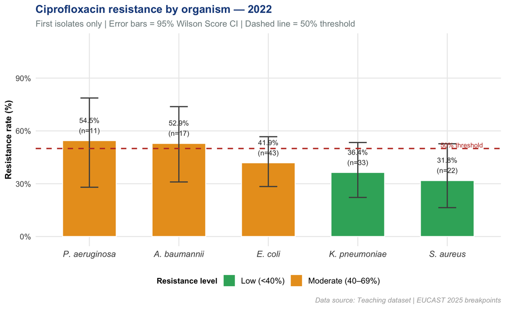

```r
# ── Add a colour variable based on resistance level ───────────────────────
cip_resistance <- cip_resistance %>%
  mutate(
    res_category = case_when(
      pct_R >= 70 ~ "High (≥70%)",
      pct_R >= 40 ~ "Moderate (40–69%)",
      TRUE        ~ "Low (<40%)"
    ),
    # Short organism labels for the axis
    org_short = case_when(
      organism == "Klebsiella pneumoniae"   ~ "K. pneumoniae",
      organism == "Escherichia coli"        ~ "E. coli",
      organism == "Staphylococcus aureus"   ~ "S. aureus",
      organism == "Pseudomonas aeruginosa"  ~ "P. aeruginosa",
      organism == "Acinetobacter baumannii" ~ "A. baumannii",
      TRUE ~ organism
    )
  )

# ── Build the bar chart ───────────────────────────────────────────────────
p_bar <- ggplot(
  cip_resistance,
  aes(x    = reorder(org_short, -pct_R),  # reorder: tallest bar first
      y    = pct_R,
      fill = res_category)
) +
  # The bars
  geom_col(width = 0.6, colour = "white") +

  # Error bars showing the 95% CI
  geom_errorbar(
    aes(ymin = ci_lo, ymax = ci_hi),
    width = 0.2, colour = "grey30", linewidth = 0.7
  ) +

  # Labels above each bar: percentage and n
  geom_text(
    aes(label = paste0(pct_R, "%\n(n=", n_tested, ")")),
    vjust = -0.5, size = 3.2, colour = "grey20"
  ) +

  # Reference line at 50% — standard threshold for "high" resistance
  geom_hline(
    yintercept = 50, linetype = "dashed",
    colour = "#c0392b", linewidth = 0.8
  ) +
  annotate(
    "text", x = 5.4, y = 52,
    label = "50% threshold", hjust = 1, size = 3, colour = "#c0392b"
  ) +

  # Colour fill: red for high, amber for moderate, green for low
  scale_fill_manual(
    values = c("High (≥70%)"       = "#e74c3c",
               "Moderate (40–69%)" = "#e99e22",
               "Low (<40%)"        = "#37ae69"),
    name = "Resistance level"
  ) +

  # y-axis: 0–110% to leave room for labels above bars
  scale_y_continuous(
    limits = c(0, 110),
    labels = function(x) paste0(x, "%")
  ) +

  # Axis labels and title
  labs(
    title    = "Ciprofloxacin resistance by organism — 2022",
    subtitle = "First isolates only | Error bars = 95% Wilson Score CI | Dashed line = 50% threshold",
    x        = NULL,
    y        = "Resistance rate (%)",
    caption  = "Data source: Teaching dataset | EUCAST 2025 breakpoints"
  ) +

  # Apply our consistent theme
  theme(
    axis.text.x = element_text(face = "italic", size = 11)
  )

# Display the plot
p_bar
```

```r
# ── Save the plot as a high-quality PNG ──────────────────────────────────
# width and height are in inches; dpi = dots per inch (300 = print quality)
ggsave(
  filename = "bar_cip_resistance.png",
  plot     = p_bar,
  width    = 9,
  height   = 5.5,
  dpi      = 300
)
```

**Interpreting this chart**

**Action implication:** The infection control team should review fluoroquinolone prescribing and consider restricting empirical use for Gram-negative hospital-acquired infections.

**Exercise 1**

Modify the bar chart code above to show **meropenem resistance** instead of ciprofloxacin.

What do you notice about the meropenem resistance rates compared to ciprofloxacin? Why is this clinically important?